# Random Graphs

December 2022

## Erdős-Rényi network

- Erdős-Rényi networks are networks produced by simple data generating process: Between each pair of vertices in an undirected graph of size \(N\), create a edge with fixed probability \(p\).
- This is a \(G(N,p)\) Erdős-Rényi network.

## Erdős-Rényi network

- There are \[ {N \choose 2} = \frac{N(N-1)}{2} \] possible edges in an \(N\) vertex graph.
- The probability that an edge is formed between any pair of vertices is \(p\).
- The probability that an edge is formed between vertices \(i\) and \(j\) is independent of the probability that edge is formed between \(i^\prime\) and \(j^\prime\).

## Erdős-Rényi network

- We can represent the edges as a sequence of random variables \[ e_1, e_2 \ldots e_{N \choose 2}, \] each of which can take a value of either \(0\) or \(1\) independently and with probability \(p\).
- Therefore, this is a Bernoulli process: \[ e_i \overset{\textrm{iid}}{\sim} \textrm{Bernoulli}(p),\quad\text{for $i \in 1\ldots {N \choose 2}$} \]

## Erdős-Rényi network: Distribution of \(L\)

- Number of edges has a binomial distribution: \(L \sim \textrm{Binomial}({N \choose 2}, p)\): \[ P(L) = {{N \choose 2} \choose L} p^L (1-p)^{{N \choose 2} - L}. \]
- The average number of edges \(\langle L \rangle\) is \(p \times {N \choose 2}\).
- The variance of number of edges: \(p \times (1-p) \times {N \choose 2}\).

## Erdős-Rényi network: Density distribution

- The graph’s density is the number of edges \(L\) over the total number of edges: \[ \text{density} = \frac{L}{N \choose 2} = \frac{L}{\frac{N(N-1)}{2}} = \frac{2L}{N(N-1)} \]
- Therefore, the probability of density \[ \frac{2L}{N(N-1)} \] is the probability of \(L\) edges.
- The average density is \[ \langle L \rangle = \frac{p \times {N \choose 2}}{{N \choose 2}} = p. \]

## Erdős-Rényi network: Degree distribution

- For each of the \(N\) vertices, there are \(N-1\) possible neighbours.
- There is a probability \(p\) that there is an edge each of the \(N-1\) neighbours.
- These probabilities are independent.
- Therefore, there is a binomial distribution over the *degrees* in the network: \[ P(k) = {N - 1 \choose 2} p^K (1-p)^{N - 1 - k}. \]

## Erdős-Rényi network: Degree distribution

- The average degree \(\langle k \rangle\) is \(p \times N -1\).
- The variance of the degree is \(p \times (1 - p) \times N -1\).

## Erdős-Rényi network: Poisson degree distribution

- When \(\langle k \rangle \ll N\), then \[ P(k) = {N - 1 \choose 2} p^K (1-p)^{N - 1 - k} \approx \textrm{Poisson}(\lambda = \langle k \rangle), \] with \(\langle k \rangle = p (N - 1)\).

## Degree distributions in real networks are not Poisson

- In a Poisson distribution with mean \(\lambda\), the standard deviation is \(\sqrt{\lambda}\) and excess kurtosis is \(1/\lambda\).
- If, for example, a friendship network was Erdős-Rényi, nearly everyone would have the same number of friends.

## Degree distributions in Facebook friendship

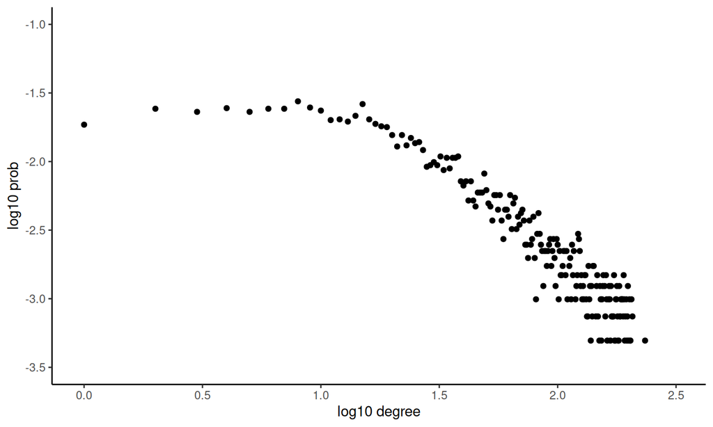

## Degree distributions in Facebook friendship, versus Poisson

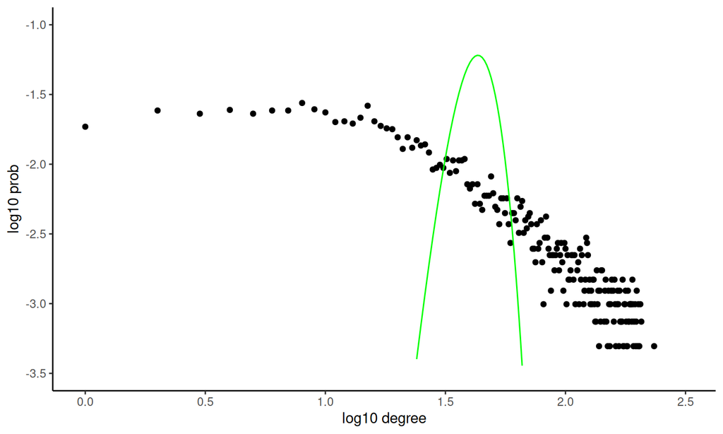

## Degree distributions in facebook friendship, versus Poisson

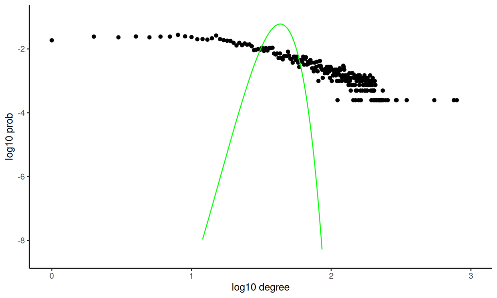

## Erdős-Rényi network: Clustering coefficient

- For a vertex \(i\) with degree \(k_i\), there are \[ {k_i \choose 2} = \frac{k_i (k_i - 1)}{2} \] possible edges in its neighbourhood.
- The probability distribution over \(L_i\), the number of edges in the neighbourhood of \(i\), is a binomial distribution of size \({k_i \choose 2}\) and probability \(p\).
- The average of this distribution is \(p \times {k_i \choose 2}\).

## Erdős-Rényi network: Clustering coefficient

- The clique coefficient of vertex \(i\) is \[ \frac{L_i}{{k_i \choose 2}} \]
- The average value of this must be \[ \frac{p \times {k_i \choose 2}}{{k_i \choose 2}} = p. \]

## Connectedness and supercriticality

- If \(\langle k \rangle < 1\), or \(p < 1/N\), the largest component is approximately zero.
- If \(\langle k \rangle \geq 1\), a *giant* component emerges.
- If \(\langle k \rangle > \ln(N)\), the network is connected with probability \(\approx 1\).

## Watts-Strogatz small-world networks

- In general, small world networks have low average distance: there are short distances between pair of nodes.
- Many real world networks have this property, as do Erdős-Rényi graphs.
- However, real world networks often do not have properties of Erdős-Rényi graphs.
- [Duncan Watts and Steven Stogatz (1998)](http://worrydream.com/refs/Watts-CollectiveDynamicsOfSmallWorldNetworks.pdf) proposed a variant of Erdős-Rényi graphs that they showed is small-world but has more properties of real wold networks.

## Watts-Strogatz small-world networks

- Start with a regular ring lattice with connections to \(2K\) neighbours, with \(K\) on either side.
- For example, here is a ring lattice with \(K=2\) neighbours on either side:

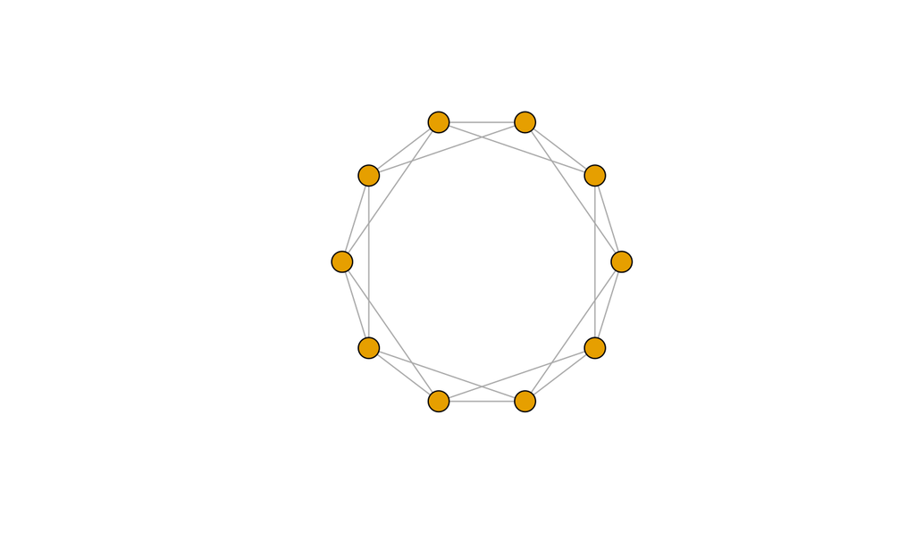

## Watts-Strogatz small-world networks

- This regular lattice has relatively high clustering coefficient, but also a high diameter relative to random graph of similar size and order.
- It is therefore realistic in terms of its clustering coefficient, but unrealistic in terms of its distances/diameter.

## Watts-Strogatz small-world networks

- To create the Watts-Strogatz network, rewire each edge in the regular ring lattice with probability \(p\).
- For example, here is a ring lattice with \(K=2\) neighbours on either side, with a rewiring probability of \(p=1/20\):

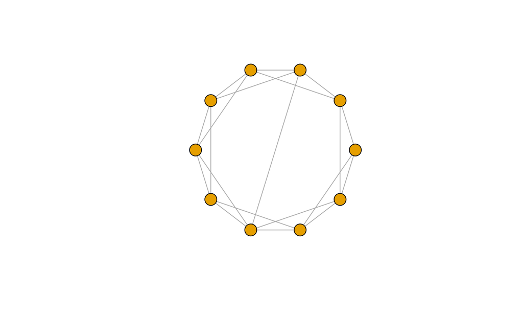

## Watts-Strogatz small-world networks

- The Watts-Strogatz network has high clique coefficients but with low average distance, a propert shared with many real world networks, e.g. neural networks, film actor networks, electrical power grid.

## Random graphs and degree distribution

- Neither the Erdős-Rényi nor Watts-Strogatz networks have degree distribution typical of many real world networks.
- Many real world networks — friendships, sexual networks, www — are heavy-tailed: some nodes have large number of connections.
- More generally, the degree distribution is a *power law*: \[ P(k) \sim k^{-\gamma}. \]
- Power law distributions are such that \[ \log(P(k)) \propto -\log(k) \]

## Power law degree distributions

- Networks formed by *preferential attachment* have power law degree distributions.
- In preferential attachment, as a network grows, new nodes form attachments to nodes with many edges.
- The probability of edge forming increases with the number of edges.
- This is known as the *Matthew effect*,

  > *For unto every one that hath shall be given, and he shall have abundance* (Matthew, 25:29)

  or the *rich-get-richer*.

## Preferential attachment network

- In a preferential attachment network, we start with one node and add new ones.
- Each time we add a new node, the probability of an edge forming to a previous node \(i\) has the probability \[ p_i \propto k_i^\alpha, \] where \(k_i\) is the degree of \(i\).

## Preferential attachment network

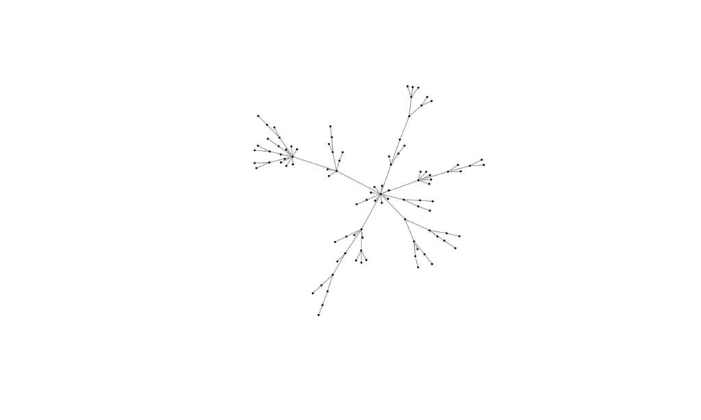